# Two Patch Population Model With Independent Demographics, Movement and Fishing

Owen Liu

December 4, 2015

## Introduction and Project Goals

This is a two-patch age-structure population model plus a fleet harvest model, in which local populations can be demographically open (i.e. subject to external larval supply and adult movement), and vary in their demographic rates. First, the model formulation will be general, then I will attempt to parameterize it for specific species.

Much of the biological model formulation is based on Caswell (2001), Armsworth(2002), and Horwood (1987) and the fleet model and example demographic parameters based on the California MLPA design process (‘California Marine Life Protection Act Initiative Draft Methods Used to Evaluate MPA Propoals in the MLPA South Coast Study Region’). The initial goals (subject to change) are to:

- investigate the consequences of variable demographic rates (growth, survival) on long-term population stability
- investigate the impact of larval and adult dispersal and their interaction and relative magnitude in comparison to variable demographics.
- investigate different models of fleet behavior and their consequences for the above.

## Model Construction

Fish populations in each of the two patches grow, die, and reproduce. They are subject to an external larval supply, along with having some rate of self-recruitment. Fishing is based on a selectivity curve, and modeled as endogenous to the age-specific survival function, and hence occurs simulateneously with natural mortality, following Caswell (2001) and Horwood (1987). Movement of larvae and adults are modeled with a connectivity matrix, and hence also occur simulaneously with growth and mortality.

### Parameters for the matrix population model(s)

Age-structured matrix model, where population is structured into $\omega$ age classes, and abundance denoted by $\textbf{N} = (N_{1},...,N_{\omega})$. A vector $\textbf{p}$ describes survival, where, for example, $p_{i}$ is the proportional survival of individuals from age $i$ to age $i+1$, subject to fishing and natural mortality. Similarly, $\textbf{f}_{i}$ is the fertility (fecundity) of individuals of age $i$. $\xi$ is the number of external larvae supplied to a local population; $a \in [0,1]$ is the self-recruitment rate, that is, the proportion of locally produced larvae that return to that population; and $\gamma$ is the proportion of settlers that remain alive at the end of the first year.

```r
max.age <- 14 # max age class (number of age classes will be this plus 1 (for age 0)
gamma <- 0.125 # proportion of settling larvae that survive the first year
ext <- 1000 # number of externally supplied larvae
e.vec <- c(1,rep(0,(max.age))) # allows addition of external larvae to the matrix
ret <- 0.5 # proportion of locally produced larvae that return (self-seeding proportion)
surv <- 0.863 # natural survival of post-settlers
mort <- 1-surv # natural mortality of post-settlers

## Rate of self-recruitment (placeholder; sampled from a beta distribution later)
a <- 0.0016

## Fishing parameters
fish <- mort #as a default, fishing intensity will equal natural mortality
q.vec <- c(0.5, rep(1,(max.age))) # selectivity is assumed to be 0.5 for age-1 fish, and 1 for age-2 plus
# note: vector of instantaneous fishing mortality rate F for each age class is equal to fish*q.vec, and total mortality Z is equal to fish*q.vec+mort.
L50 <- 25 # length (cm) at 50% selectivity
L95 <- 40 # length (cm) at 50% selectivity


## Von Bertalanffy parameters
Linf <- 52.2 #L infinity, asymptotic length
K <- 0.354 #growth rate
t0 <- -0.766 #theoretical age at zero length
vb <- c(Linf, K, t0) #concatenated 3 V-B growth params

## weight-at-length parameters, of the form a*L^b (from FishBase)
lw.a <- 0.0105
lw.b <- 3.11

## Fecundity/fertility/length relationship (assume knife-edge maturity at age at first reproduction)
repr.age <- 2 #age at first reproduction
fert1 <- 0.0129
fert2 <- 3.03
mature.vec <- c(rep(0,repr.age-1),rep(1,max.age+2-repr.age))

## Beverton-Holt parameter, for density-dependent model
B <- 1.1 # (B-H beta parameter)

## Years for each simulation
sim.years <- 200
```

#### Von Bertalanffy Growth

The classic Von Bertalanffy Growth equation, of the form

$L(t) = L_\infty(1-e^{-K(t-t_0)})$

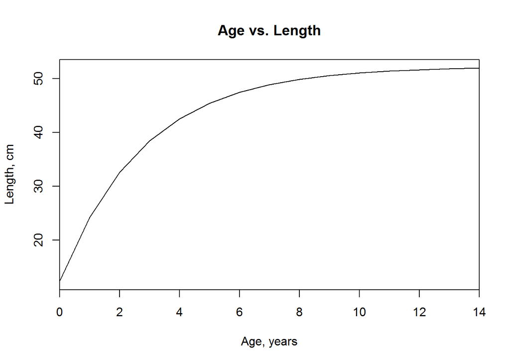

```r
vb.growth <- function(age.vec,vb)  {
  ## function that takes an age vector and a vector of V-B params, c(Linf, K, t0)
  ## returns a vector of lengths
  lengths <- sapply(age.vec, function(x) vb[1]*(1-exp(-vb[2]*(x-vb[3]))))
  return(lengths)
  }

## with our parameters:
l.vec <- vb.growth(age.vec=0:max.age,vb=vb) #vector of lengths (to be used later)
plot(0:max.age,l.vec,main="Age vs. Length",type='l',xlab='Age, years',ylab='Length, cm',
     xaxs='i')
```

#### Selectivity-at-age

Selectivity at age is calculated by first converting age to length, then using a logistic relationship

$q=\frac{1}{1+e^{-ln(19)(L-L_{50})/(L_{95}-L_{50})}}$

to calculate a selectivity vector, where $L$ is length, $L_{50}$ is length at 50% vulnerability to the gear, and $L_{95}$ is length at 95% vulnerability. Selectivity-at-age is used in calculations of fisheries yield and cohort survival.

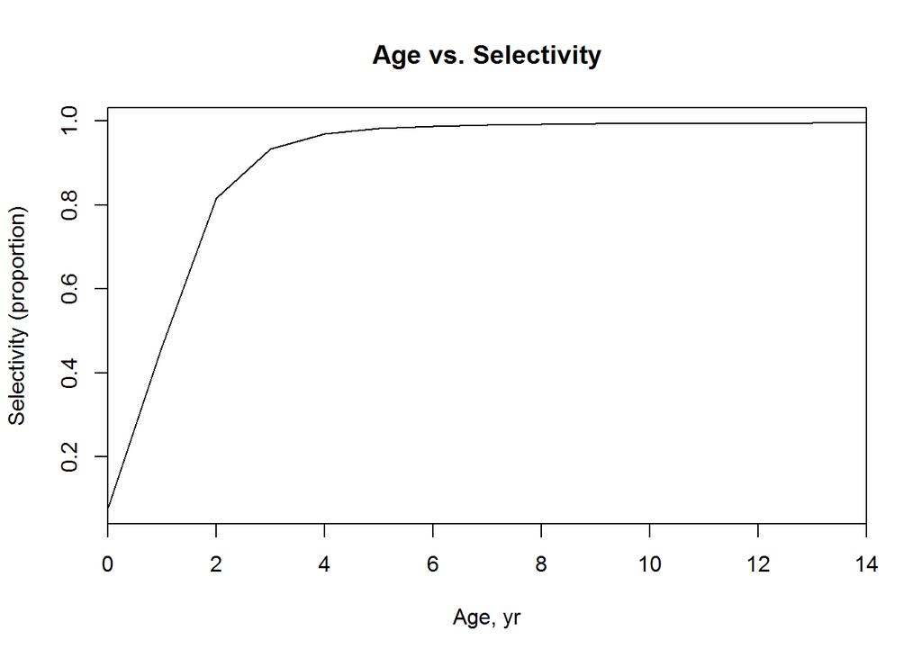

```r
###Logistic selectivity curve converts age to length (cm) to selectivity [0,1]
#using parameters L50 (length at 50% selectivity), and L95 (length
#at 95% selectivity. Based on Punt and Kennedy (1997)
selectivity.at.length <- function(vb,age.vec, L50, L95) {
  l.vec <- vb.growth(age.vec=0:max.age,vb=vb)
  sel.vec <- 1/(1+exp(-1*log(19)*(l.vec-L50)/(L95-L50)))
  return(sel.vec)
}
q.vec <- selectivity.at.length(vb=vb,age.vec=0:max.age, L50=L50, L95=L95)
plot(0:max.age,q.vec,main="Age vs. Selectivity",type='l',xlab='Age, yr',ylab='Selectivity (proportion)',
     xaxs='i')
```

#### Survival function, including fishing and natural mortality

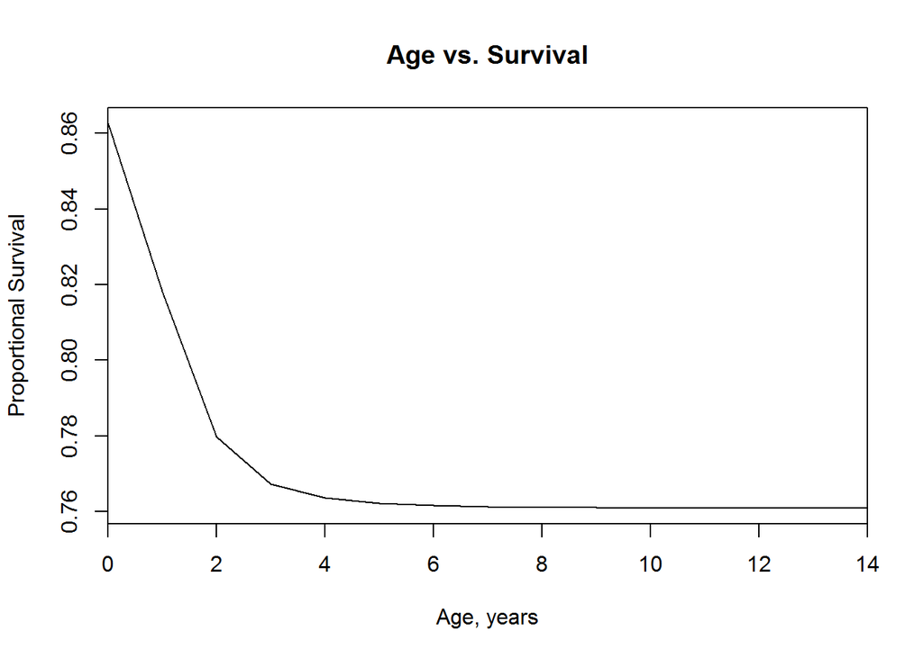

```r
surv.fxn <- function(fish, q.vec, mort) {
  p.vec <- exp(-fish*q.vec-mort)
  # where fish is the fishing intensity, q.vec is the selectivity vector, and mort is natural mortality
  return(p.vec)
}
## with our parameters:
p.vec <- surv.fxn (fish=fish,q.vec=q.vec,mort=mort)
plot(0:max.age,p.vec,main="Age vs. Survival",type='l',xlab='Age, years',ylab='Proportional Survival',
     xaxs='i')
```

#### Fecundity relationship

This function relates length to fecundity, and is a power function that can be parameterized on a species-specific basis. Fecundity at age zero to reproductive age was zero, and otherwise followed the form:

$f_i = f_1L_i^{f_2}$

where $f_i$ is fecundity at age $i$, and $f_1$ and $f_2$ are parameters. Adopted from Sadovy (1996)

*Note: fecundity is zero until reproductive age (a parameter above) is reached*

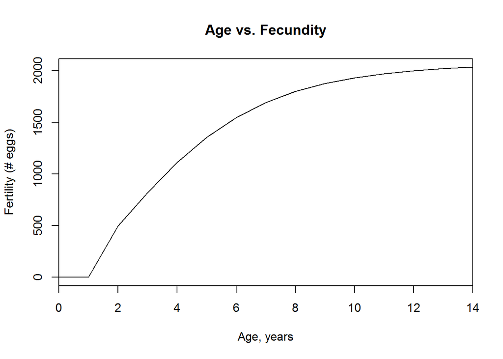

```r
 fert <- function(age.vec, vb, repr.age, fert1,fert2) {
  ## function that builds on VB equation above, taking three more parameters to calculate fertility
  ## as a function of age.
  ## From Armsworth (2002) and Sadovy (1996)
  l.vec <- vb.growth(age.vec=age.vec,vb=vb)
  f <- sapply(l.vec, function(x) fert1*x^fert2)
  f[1:repr.age] <- 0
  return(f)
}

# with our parameters:
fert.vec <- fert(age.vec=0:max.age,vb=vb,repr.age=repr.age,fert1=fert1,fert2=fert2)
plot(0:max.age,fert.vec,main="Age vs. Fecundity",type='l',xlab='Age, years',ylab='Fertility (# eggs)',
     xaxs='i')
```

#### Weight-at-age

Weight at age is calculated by first converting age to length, then using the relationship $W=aL^{b}$ to calculate a vector of weights. Weight-at-age is used to calculate spawning stock biomass and biomass yield for fisheries.

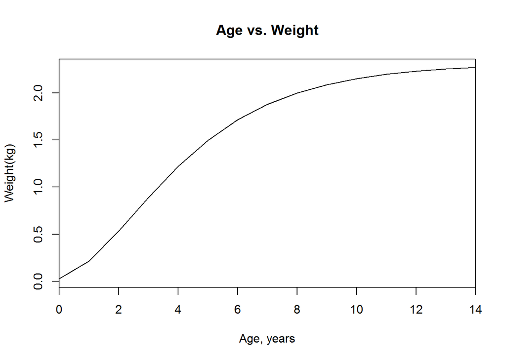

```r
weight.at.age <- function(vb,age.vec,lw.a,lw.b) {
  # first, age to length
  l.vec <- vb.growth(age.vec=age.vec,vb=vb)
  #then, weights-by-length (divide by 1000 for g to kg)
  w.vec <- lw.a*l.vec^(lw.b)/1000
  return(w.vec)
}
# with our parameters:
w.vec <- weight.at.age(age.vec=0:max.age,vb=vb,lw.a=lw.a,lw.b=lw.b)
plot(0:max.age,w.vec,main="Age vs. Weight",type='l',xlab='Age, years',ylab='Weight(kg)',
     xaxs='i')
```

#### Spawning stock biomass

Spawning stock biomass is function of weight-at-age, numbers-at-age, and proportion mature at age

$SSB = \sum_{i=1}^{\omega}w_in_iMat_i$

```r
ssb <- function(w.vec,n.vec,mature.vec) sum(w.vec*n.vec*mature.vec)
```

#### Fisheries Yield

$Y = \sum_{i=1}^{\omega}F_{rel,i}w_in_i$

where $F_rel$ is exploitation fraction. The output will be a total catch in kg, subject to fishery selectivity and all of the demographic parameters and relationships defined above. This equation will require the outputs of most of the equations above.

```r
yield <- function(fish,q.vec,mort,w.vec,n.vec) {
  expl.rate<-(fish*q.vec)/(fish*q.vec+mort) # exploitation rate is equal to the ratio of fishing mortality (F=f*q) to total mortality (F+M). This equation returns an age-specific exploitation rate
  y.vec <- expl.rate*w.vec*n.vec # yield by age
  return(sum(y.vec)) # total yield
}
```

#### Net Reproductive Rate

The net reproductive rate, $R$, is a useful concept, and is defined as the expected lifetime reproductive contribution from an individual that survives the first year, from Caswell (2001). $R$ is useful because if $R\gamma$*a* (the expected per capita lifetime production of recruits) is less than 1, we can expect than the population will shrink (below replacement level; i.e. a *sink* population) because an individual is not expected to replace itself. The converse is also true, that when $R\gamma$*a* is greater than 1, the population will be a *source* :

$R = \sum_{i=1}^{\omega}f_{1}\prod_{k=0}^{i-1}p_{k}$

```r
net.R <- function(fert.vec,p.vec) {
  p.cum <- numeric()
  for (i in 1:(max.age+1)) { #cumulative survival (i.e. vector of prob. surviving age 0:x)
    p.cum[i] <- prod(p.vec[1:i])
  }
  R <- sum(fert.vec*p.cum)
  return(R)
}
```

## Local population

The density-independent model for a local population takes the form

$\textbf{N}(\textit{t} + 1) = \textbf{MN}(\textit{t}) + \gamma\xi\textbf{e}$

where **M** is a Leslie matrix, $\gamma$ is the proportion of settlers that survive the year, $\xi$ is the number of externally supplied larvae, and **e** is a vector to allow external larvae to affect the matrix. We will also use the defined parameter *a* $\in$ [0,1], which is the proportion of locally produced larvae that return to the same local adult population, i.e. the rate of self-recruitment.

We can now construct the Leslie matrix **M** :

```r
M.di <- function (max.age,a, gamma, fert.vec, p.vec) {
  M=matrix(nrow=max.age+1,ncol=max.age+1)
  r1 <- fert.vec*a*gamma #first row, allowing for a partially open population and settler mortality in year 1
  M[1,] <-r1
  for (i in 2:(max.age+1)) { #rows 2 to max age
    row <- numeric(max.age+1)
    row[i-1] <- p.vec[i]
    M[i,] <- row
  }
  return(M)
}

## a vector of stable age distribution (at equilibrium) can be calculated from the right eigenvector of the M matrix
## we will use this later to 'seed' simulations with appropriate abundances
stableage <- Re(eigen(M.di(max.age=max.age,a=a,gamma=gamma,fert.vec=fert.vec,p.vec=p.vec))$vector)[,1]
stableage <- stableage/sum(stableage)
```

In this model formulation, the long-term growth or decline is determined by $R$ (or, equivalently, by the dominant eigenvalue of **M**), and consequently by the self-recruitment rate *a*. Whether the population will grow or decline in the long-term is *not* determined by $\xi$, since it is an additive, not a multiplicative term. $\xi$ will, however, influence abundance.

### Simulations for Local Population

To start, we can explore the behavior of these models by simulating a virtual population, described by the parameters above, and look at patterns over time in age structure and population dynamics. First, we can write a general simulation function, and apply it to the density independent local population.

We can sample $a\in(0,1)$ from a skewed beta distribution, Beta$(\alpha,\beta)$, since in most years it will be very small. $\xi$, the external larval supply, is sampled from a lognormal distribution (both following Armsworth 2002). The cv of both $a$ and $\xi$ are the same, cv=0.5.

One more source of randomization: Every year of the simulation, all demographic parameters are subject to a $\pm$ 12.5% fluctuation. This randomization applies to survival vector $\textbf{p}$, larval survival $\gamma$, and fecundity vector $\textbf{f}$

```r
## Calls all the parts we've coded so far
sim.dipop <- function(nyears=200,max.age=14,Linf=52.2,K=0.354,t0 = -0.766, surv=0.863, mort=1-0.863, repr.age=2, gamma=0.125,fert1=0.0129,fert2=3.03, fish=0, L50=25,L95=40, lw.a=0.0105, lw.b=3.11, a.mu=0.001,a.cv=0.5, ext.mean=1000, ext.cv=0.5) {
  ## age vector
  age.vec <- 0:max.age

  ## lengths vector
  vb <- c(Linf,K,t0)
  l.vec <- vb.growth(age.vec=age.vec,vb=vb)

  ## fertility vector
  fert.vec <- fert(age.vec=age.vec,vb=vb,repr.age=repr.age,fert1=fert1,fert2=fert2)

  ## selectivity-at-age
  q.vec <- selectivity.at.length(vb=vb,age.vec=0:max.age, L50=L50, L95=L95)

  ## survival vector
  p.vec <- surv.fxn(fish=fish, q.vec=q.vec,mort=mort)

  ## maturity-at-age
  mature.vec <- c(rep(0,repr.age-1),rep(1,max.age+2-repr.age))

  ## weight-at-age
  w.vec <- weight.at.age(age.vec=age.vec,vb=vb,lw.a=lw.a,lw.b=lw.b)

  ## allows external larvae to affect the matrix
  e.vec <- c(1,rep(0,(max.age)))

  ## stable age distribution (for seeding simulation)
  stableage <- Re(eigen(M.di(max.age=max.age,a=a.mu,gamma=gamma,fert.vec=fert.vec,p.vec=p.vec))$vector)[,1]
  stableage <- stableage/sum(stableage)

  ## parameters and vector for beta-distributed a (self-recruitment rate)
  a.alpha <- estBetaParams(mu=a.mu,cv=a.cv)[[1]]
  a.beta <- estBetaParams(mu=a.mu,cv=a.cv)[[2]]
  a.rand <- rbeta(n=nyears,shape1=a.alpha,shape2=a.beta)
  if(a.mu==0) a.rand<-rep(0,nyears)

  ## parameters and vector for log-norm-distributed ext (number of external larvae)
  ext.meanlog <- estlnormParams(mean=ext.mean,cv=ext.cv)[[1]]
  ext.sdlog <- estlnormParams(mean=ext.mean,cv=ext.cv)[[2]]
  ext.rand <- rlnorm(n=nyears,meanlog=ext.meanlog,sdlog=ext.sdlog)

  ## the simulation output matrix
  d.i.sim <- matrix(nrow=(max.age+1), ncol=nyears)
  d.i.simtot <- numeric() # total population
  Ninit <- rep(250,15)*stableage # starting abundance
  d.i.sim[,1] <- Ninit
  d.i.simtot <- sum(Ninit)
  eigens <- numeric() # for holding eigenvalues
  Radj <- numeric() # for holding "adjusted" R values (R*gamma*a in each year)
  SSB <- numeric() # for holding value of SSB in each year
  Yield <- numeric() #for holding value of yield in each year

  ## run the simulation
  for (i in 1:(nyears-1)) {
    demo.rand <- runif(1,min=0.875,max=1.125) # allows uniform random synchronous variation
    M <- M.di(max.age=max.age,a=a.rand[i], gamma=gamma*demo.rand, fert.vec=fert.vec*demo.rand, p.vec=p.vec*demo.rand)
    eigens[i] <- eigen(M)[[1]][1] #store the dominant eigen value
    Radj[i] <- net.R(fert.vec=fert.vec*demo.rand,p.vec=p.vec*demo.rand)*(gamma*demo.rand)*a.rand[i]
    N.vec <- M%*%d.i.sim[,i] + (gamma*ext.rand[i]*e.vec)
    d.i.sim[,i+1] <- N.vec
    d.i.simtot[i+1] <- sum(N.vec)
    SSB[i] <- ssb(w.vec=w.vec,n.vec=d.i.sim[,i],mature.vec=mature.vec)
    Yield[i] <- yield(fish=fish,q.vec=q.vec,mort=mort,w.vec=w.vec,n.vec=d.i.sim[,i])
  }
  ## for the last year
  demo.rand <- runif(1,min=0.875,max=1.125) # allows uniform random synchronous variation
  M <- M.di(max.age=max.age,a=a.rand[nyears], gamma=gamma*demo.rand, fert.vec=fert.vec*demo.rand,
            p.vec=p.vec*demo.rand)
  eigens[nyears] <- eigen(M)[[1]][1] #store the dominant eigen value
  Radj[nyears] <- net.R(fert.vec=fert.vec*demo.rand,p.vec=p.vec*demo.rand)*(gamma*demo.rand)*a.rand[nyears]
  SSB[nyears] <- ssb(w.vec=w.vec,n.vec=d.i.sim[,nyears],mature.vec=mature.vec)
  Yield[nyears] <- yield(fish=fish,q.vec=q.vec,mort=mort,w.vec=w.vec,n.vec=d.i.sim[,nyears])

  ## Returns a list with the last 100 years of the simulation, including population (every age class), total population summed over age classes, proportional population in each age class, eigenvalues of each year's matrix, and Reproductive Value for the average individual each year, adjusted for settler survival (gamma) and self-recruitment rate a.
  return(list(pop=d.i.sim[,(nyears-99):nyears],tot=d.i.simtot[(nyears-99):nyears],props=apply(d.i.sim,
              MARGIN=2,FUN=function(x) x/sum(x))[,(nyears-99):nyears], eigens=Re(eigens[(nyears-99):nyears]),
              Radj=Radj[(nyears-99):nyears],SSB=SSB[(nyears-99):nyears],Yield=Yield[(nyears-99):nyears]))
}
```

We can start to test the sensitivity of outputs to variation in input parameters. First, to self-recruitment rate *a*:

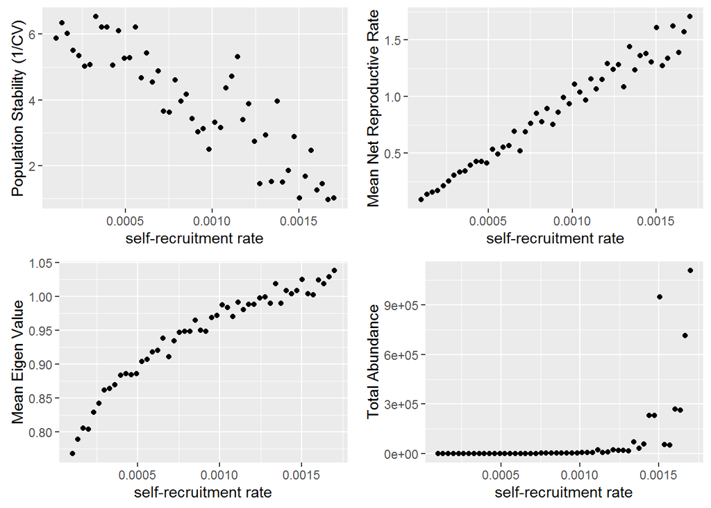

What about sensitivity to mean external larval supply?

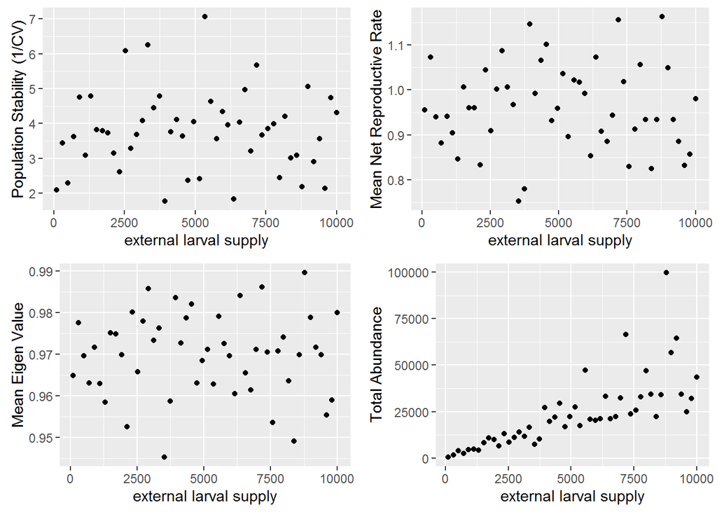

Fishing has been zero. What is the effect of adding (static, for now) fishing mortality? Here we test sensitivity to fishing intensity, from 0 to 1. For now, selectivity is constant, so fishing intensity is analagous to fishing mortality F. Here, too, we get fisheries yield (when previously it was zero).

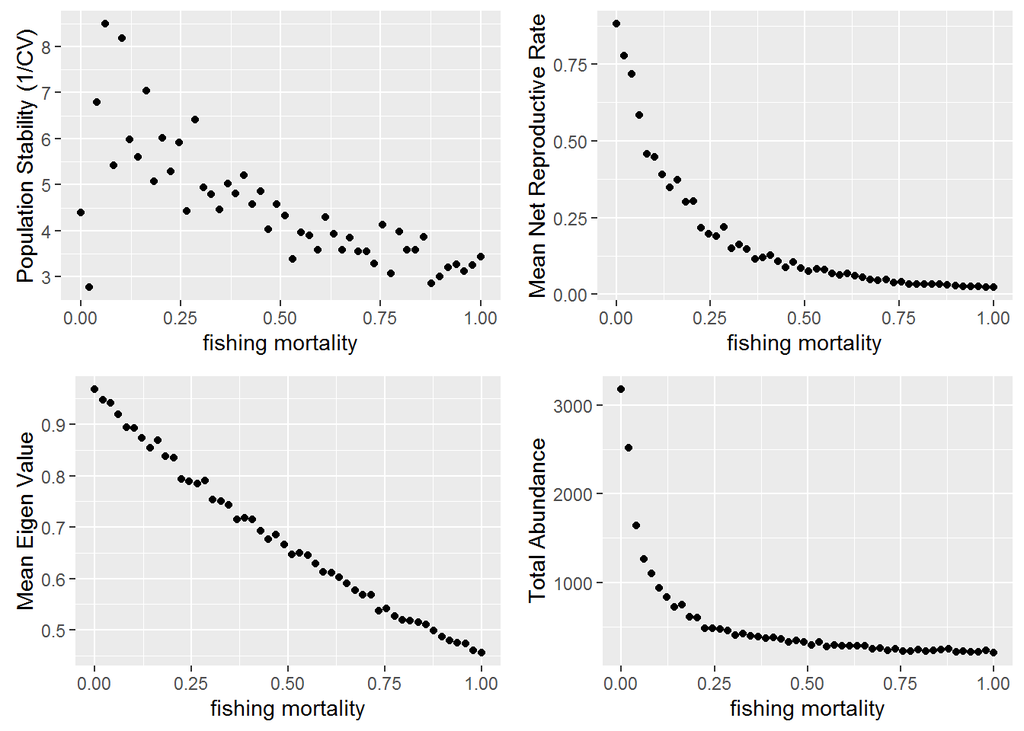

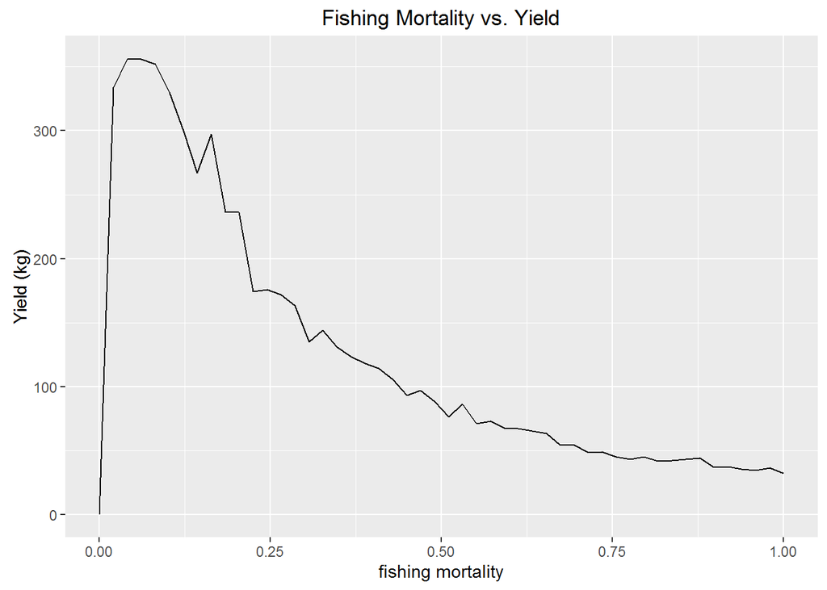

## Two separate, interacting populations

Next, we set up two populations that interact through larval and adult movement, but they can have separate demographic rates (growth, natural mortality, larval survival, length-weight relationship, etc.) and can be subject to different fishing pressures. Basically, the model formulation allows for separate parameter values for most of the parameters used in the single-population example above, while also adding larval and adult movement. Default demographic and fishing parameters are identical between populations. The metapopulation formulation requires an $\omega$ x $\omega$ square matrix $\textbf{Q}$ describing connectivity. If $a_{ij}^{\omega}$ is the proportion of age class $\omega$ produced by population $j$ that move to local population $i$, then $^{ij}\textbf{Q}$ is the square matrix with top line $a_{ij} ^{i}\gamma(^{j}f_{1},...,^{j}f_{\omega})$ , allowing larvae from produced in population $j$ to affect population $i$, and other rows either zero (for no adult movement) or containing proportional movement of individuals of other age classes from $j$ to $i$. Following Armsworth (2002) and Caswell (2001).

Random environmental fluctuation in recruitment (self-recruitment rate) can also be parameterized separately. There is no more external larvae ($\xi$) term, since the 2 patches are assumed to contain the entire population, and hence the population is demographically ‘closed’ at the metapopulation level.

```r
## Movement matrix function
# parameter 'larvala' describes proportional movement of larvae from one population to the other, 'adulta' describes proportional movement of adults. Before, 'a' represented self-recruitment rate. In Q, 'a' is rate of recruitment or movement into the local population from a different population.

Q.fxn <- function (max.age,larvala, adulta, gamma, fert.vec,p.vec) {
  Q=matrix(nrow=max.age+1,ncol=max.age+1) # square matrix, with each dimension equal to the number of age classes
  r1 <- fert.vec*larvala*gamma #first row, which combines larval production in the outside population, proportional recruitment into the local population, and larval survival. IMPORTANT that the fert.vec used here is not for the local population (that will be accounted for in M), but for the outside population that is seeding the local population.
  Q[1,] <-r1
  for (i in 2:(max.age+1)) { #rows 2 to max age
    row <- numeric(max.age+1)
    row[i-1] <- adulta*p.vec[i]
    Q[i,] <- row
  }
  return(Q)
}

## 2 population simulation function
## Calls all the parts we've coded so far
sim.2pops <- function(nyears=200,max.age=14,Linf.1=52.2,K.1=0.354,t0.1 = -0.766, surv.1=0.863, mort.1=1-0.863, repr.age.1=2, gamma.1=0.125,fert1.1=0.0129,fert2.1=3.03, fish.1=0, L50.1=25,L95.1=40, lw.a.1=0.0105, lw.b.1=3.11, a.mu.1=0.001,a.cv.1=0.5,Linf.2=52.2,K.2=0.354,t0.2 = -0.766, surv.2=0.863, mort.2=1-0.863, repr.age.2=2, gamma.2=0.125,fert1.2=0.0129,fert2.2=3.03, fish.2=0, L50.2=25,L95.2=40, lw.a.2=0.0105, lw.b.2=3.11, a.mu.2=0.001,a.cv.2=0.5, larvala.mu.1=0.0005,larvala.cv.1=0.5,adulta.mu.1=0,adulta.cv.1=0.5,larvala.mu.2=0.0005,larvala.cv.2=0.5,adulta.mu.2=0,adulta.cv.2=0.5) {

  ### First population
  ## age vector
  age.vec <- 0:max.age

  ## lengths vector
  vb.1 <- c(Linf.1,K.1,t0.1)
  l.vec.1 <- vb.growth(age.vec=age.vec,vb=vb.1)

  ## fertility vector
  fert.vec.1 <- fert(age.vec=age.vec,vb=vb.1,repr.age=repr.age.1,fert1=fert1.1,fert2=fert2.1)

  ## selectivity-at-age
  q.vec.1 <- selectivity.at.length(vb=vb.1,age.vec=0:max.age, L50=L50.1, L95=L95.1)

  ## survival vector
  p.vec.1 <- surv.fxn(fish=fish.1, q.vec=q.vec.1,mort=mort.1)

  ## maturity-at-age
  mature.vec.1 <- c(rep(0,repr.age.1-1),rep(1,max.age+2-repr.age.1))

  ## weight-at-age
  w.vec.1 <- weight.at.age(age.vec=age.vec,vb=vb.1,lw.a=lw.a.1,lw.b=lw.b.1)

  ## allows external larvae to affect the matrix
  e.vec <- c(1,rep(0,(max.age)))

  ## stable age distribution (for seeding simulation)
  stableage.1 <- Re(eigen(M.di(max.age=max.age,a=a.mu.1,gamma=gamma.1,fert.vec=fert.vec.1,p.vec=p.vec.1))$vector)[,1]
  stableage.1 <- stableage/sum(stableage)

  ## parameters and vector for beta-distributed a (self-recruitment rate)
  a.alpha.1 <- estBetaParams(mu=a.mu.1,cv=a.cv.1)[[1]]
  a.beta.1 <- estBetaParams(mu=a.mu.1,cv=a.cv.1)[[2]]
  a.rand.1 <- rbeta(n=nyears,shape1=a.alpha.1,shape2=a.beta.1)
  if(a.mu.1==0) a.rand.1<-rep(0,nyears)

  ### Second population
  ## age vector
  age.vec <- 0:max.age

  ## lengths vector
  vb.2 <- c(Linf.2,K.2,t0.2)
  l.vec.2 <- vb.growth(age.vec=age.vec,vb=vb.2)

  ## fertility vector
  fert.vec.2 <- fert(age.vec=age.vec,vb=vb.2,repr.age=repr.age.2,fert1=fert1.2,fert2=fert2.2)

  ## selectivity-at-age
  q.vec.2 <- selectivity.at.length(vb=vb.2,age.vec=0:max.age, L50=L50.2, L95=L95.2)

  ## survival vector
  p.vec.2 <- surv.fxn(fish=fish.2, q.vec=q.vec.2,mort=mort.2)

  ## maturity-at-age
  mature.vec.2 <- c(rep(0,repr.age.2-1),rep(1,max.age+2-repr.age.2))

  ## weight-at-age
  w.vec.2 <- weight.at.age(age.vec=age.vec,vb=vb.2,lw.a=lw.a.2,lw.b=lw.b.2)

  ## allows external larvae to affect the matrix
  e.vec <- c(1,rep(0,(max.age)))

  ## stable age distribution (for seeding simulation)
  stableage.2 <- Re(eigen(M.di(max.age=max.age,a=a.mu.2,gamma=gamma.2,fert.vec=fert.vec.2,p.vec=p.vec.2))$vector)[,1]
  stableage.2 <- stableage/sum(stableage)

  ## parameters and vector for beta-distributed a (self-recruitment rate)
  a.alpha.2 <- estBetaParams(mu=a.mu.2,cv=a.cv.2)[[1]]
  a.beta.2 <- estBetaParams(mu=a.mu.2,cv=a.cv.2)[[2]]
  a.rand.2 <- rbeta(n=nyears,shape1=a.alpha.2,shape2=a.beta.2)
  if(a.mu.2==0) a.rand.2<-rep(0,nyears)

    ## Random, beta-distributed larval and adult connectivity, pop2 to pop1, based on mean larval connectivity larvala.mu.1, and mean adult connectivity adulta.mu.1
  larvala.alpha.12 <- estBetaParams(mu=larvala.mu.1,cv=larvala.cv.1)[[1]]
  larvala.beta.12 <- estBetaParams(mu=larvala.mu.1,cv=larvala.cv.1)[[2]]
  larvala.rand.12 <- rbeta(n=nyears,shape1=larvala.alpha.12,shape2=larvala.beta.12)
  if(larvala.mu.1==0) larvala.rand.12<-rep(0,nyears) # corrects for an error in rbeta() when params are zero (for zero connectivity)
  adulta.alpha.12 <- estBetaParams(mu=adulta.mu.1,cv=adulta.cv.1)[[1]]
  adulta.beta.12 <- estBetaParams(mu=adulta.mu.1,cv=adulta.cv.1)[[2]]
  adulta.rand.12 <- rbeta(n=nyears,shape1=adulta.alpha.12,shape2=adulta.beta.12)
  if(adulta.mu.1==0) adulta.rand.12<-rep(0,nyears)

  ## Random, beta-distributed larval and adult connectivity, pop1 to pop2 based on mean larval connectivity larvala.mu.2, and mean adult connectivity adulta.mu.2
  larvala.alpha.21 <- estBetaParams(mu=larvala.mu.2,cv=larvala.cv.2)[[1]]
  larvala.beta.21 <- estBetaParams(mu=larvala.mu.2,cv=larvala.cv.2)[[2]]
  larvala.rand.21 <- rbeta(n=nyears,shape1=larvala.alpha.21,shape2=larvala.beta.21)
  if(larvala.mu.2==0) larvala.rand.21<-rep(0,nyears) # corrects for an error in rbeta() when params are zero (for zero connectivity)
  adulta.alpha.21 <- estBetaParams(mu=adulta.mu.2,cv=adulta.cv.2)[[1]]
  adulta.beta.21 <- estBetaParams(mu=adulta.mu.2,cv=adulta.cv.2)[[2]]
  adulta.rand.21 <- rbeta(n=nyears,shape1=adulta.alpha.21,shape2=adulta.beta.21)
  if(adulta.mu.2==0) adulta.rand.21<-rep(0,nyears)

  ## the simulation output holders (pop 1)
  sim.1 <- matrix(nrow=(max.age+1), ncol=nyears)
  simtot.1 <- numeric() # total population
  Ninit.1 <- rep(250,15)*stableage.1 # starting abundance (subpop 1)
  sim.1[,1] <- Ninit.1
  simtot.1[1] <- sum(Ninit.1)
  eigens.1 <- numeric() # for holding eigenvalues
  Radj.1 <- numeric() # for holding "adjusted" R values (R*gamma*a in each year)
  SSB.1 <- numeric() # for holding value of SSB in each year
  Yield.1 <- numeric() #for holding value of yield in each year
```

```r
  ## the simulation output holders (pop 2)
  sim.2 <- matrix(nrow=(max.age+1), ncol=nyears)
  simtot.2 <- numeric() # total population
  Ninit.2 <- rep(250,15)*stableage.2 # starting abundance (subpop 2)
  sim.2[,1] <- Ninit.2
  simtot.2[1] <- sum(Ninit.2)
  eigens.2 <- numeric() # for holding eigenvalues
  Radj.2 <- numeric() # for holding "adjusted" R values (R*gamma*a in each year)
  SSB.2 <- numeric() # for holding value of SSB in each year
  Yield.2 <- numeric() #for holding value of yield in each year

  ## the simulation output holders (total pop)
  sim.all <- matrix(nrow=2*(max.age+1), ncol=nyears)
  simtot.all <- numeric() # total population
  sim.all[,1] <- c(Ninit.1,Ninit.2)
  simtot.all[1] <- sum(Ninit.1,Ninit.2)
  eigens.all <- numeric() # for holding eigenvalues
  SSB.all <- numeric() # for holding value of SSB in each year
  Yield.all <- numeric() #for holding value of yield in each year

  ## Run the simulation
  for (i in 1:(nyears-1)) {
    ## Movement matrices Q12 (transitions and reproduction of individuals the move from patch 2 to patch 1) and Q21       (transitions and reproduction of individuals the move from patch 1 to patch 2). Remember, the fertility vector        corresponds to the outside population, and all other survival and recruitment-rate terms correspond to the local      population.
    Q.12 <- Q.fxn(max.age=max.age,larvala=larvala.rand.12[i], adulta=adulta.rand.12[i],
                  gamma=gamma.1,fert.vec=fert.vec.2,p.vec=p.vec.1)
    Q.21 <- Q.fxn(max.age=max.age,larvala=larvala.rand.21[i], adulta=adulta.rand.21[i],
                  gamma=gamma.2,fert.vec=fert.vec.1,p.vec=p.vec.2)

    ## Local transition matrices M1 and M2
    demo.rand <- runif(1,min=0.875,max=1.125) # allows uniform random synchronous variation in demographic rates
    M.1 <- M.di(max.age=max.age,a=a.rand.1[i], gamma=gamma.1*demo.rand, fert.vec=fert.vec.1*demo.rand,
                p.vec=p.vec.1*demo.rand)
    M.2 <- M.di(max.age=max.age,a=a.rand.2[i], gamma=gamma.2*demo.rand, fert.vec=fert.vec.2*demo.rand,
                p.vec=p.vec.2*demo.rand)

    #Projection matrix A, including M and Q
    A <- rbind(cbind(M.1,Q.12),cbind(Q.21,M.2))

    ## update all the variables we're tracking

    # total pop
    eigens.all[i] <- eigen(A)[[1]][1]
    N.vec <- A%*%sim.all[,i]
    sim.all[,i+1] <- N.vec
    simtot.all[i+1] <- sum(N.vec)

    # pop 1
    eigens.1[i] <- eigen(M.1)[[1]][1]
    Radj.1[i] <- net.R(fert.vec=fert.vec.1*demo.rand,p.vec=p.vec.1*demo.rand)*(gamma.1*demo.rand)*a.rand.1[i]
    sim.1[,i+1] <- N.vec[1:(max.age+1)]
    simtot.1[i+1] <- sum(N.vec[1:(max.age+1)])
    SSB.1[i] <- ssb(w.vec=w.vec.1,n.vec=sim.1[,i],mature.vec=mature.vec.1)
    Yield.1[i] <- yield(fish=fish.1,q.vec=q.vec.1,mort=mort.1,w.vec=w.vec.1,n.vec=sim.1[,i])

    # pop 2
    eigens.2[i] <- eigen(M.2)[[1]][1]
    Radj.2[i] <- net.R(fert.vec=fert.vec.2*demo.rand,p.vec=p.vec.2*demo.rand)*(gamma.2*demo.rand)*a.rand.2[i]
    sim.2[,i+1] <- N.vec[(max.age+2):length(N.vec)]
    simtot.2[i+1] <- sum(N.vec[(max.age+2):length(N.vec)])
    SSB.2[i] <- ssb(w.vec=w.vec.2,n.vec=sim.2[,i],mature.vec=mature.vec.2)
    Yield.2[i] <- yield(fish=fish.2,q.vec=q.vec.2,mort=mort.2,w.vec=w.vec.2,n.vec=sim.2[,i])

    # total SSB and yield
    SSB.all[i] <- sum(SSB.1[i],SSB.2[i])
    Yield.all[i] <- sum(Yield.1[i],Yield.2[i])

  }
  ## FOR THE FINAL YEAR
  demo.rand <- runif(1,min=0.875,max=1.125) # allows uniform random synchronous variation in demographic rates
    M.1 <- M.di(max.age=max.age,a=a.rand.1[i], gamma=gamma.1*demo.rand, fert.vec=fert.vec.1*demo.rand,
                p.vec=p.vec.1*demo.rand)
    M.2 <- M.di(max.age=max.age,a=a.rand.2[i], gamma=gamma.2*demo.rand, fert.vec=fert.vec.2*demo.rand,
                p.vec=p.vec.2*demo.rand)

  #Projection matrix A, including M and Q
  A <- rbind(cbind(M.1,Q.12),cbind(Q.21,M.2))

  ## update all the variables we're tracking

  # total pop
  eigens.all[nyears] <- eigen(A)[[1]][1]

  # pop 1
  eigens.1[nyears] <- eigen(M.1)[[1]][1]
  Radj.1[nyears] <- net.R(fert.vec=fert.vec.1*demo.rand,p.vec=p.vec.1*demo.rand)*(gamma.1*demo.rand)*a.rand.1[nyears]
  SSB.1[nyears] <- ssb(w.vec=w.vec.1,n.vec=sim.1[,nyears],mature.vec=mature.vec.1)
  Yield.1[nyears] <- yield(fish=fish.1,q.vec=q.vec.1,mort=mort.1,w.vec=w.vec.1,n.vec=sim.1[,nyears])

  # pop 2
  eigens.2[nyears] <- eigen(M.2)[[1]][1]
  Radj.2[nyears] <- net.R(fert.vec=fert.vec.2*demo.rand,p.vec=p.vec.2*demo.rand)*(gamma.2*demo.rand)*a.rand.2[nyears]
  SSB.2[nyears] <- ssb(w.vec=w.vec.2,n.vec=sim.2[,nyears],mature.vec=mature.vec.2)
  Yield.2[nyears] <- yield(fish=fish.2,q.vec=q.vec.2,mort=mort.2,w.vec=w.vec.2,n.vec=sim.2[,nyears])

  # total SSB and yield
  SSB.all[nyears] <- sum(SSB.1[nyears],SSB.2[nyears])
  Yield.all[nyears] <- sum(Yield.1[nyears],Yield.2[nyears])

## Returns a list of 3 lists of the simulation, including population (every age class), total population summed over age classes, proportional population in each age class, eigenvalues of each year's matrix, and Reproductive Value for the average individual each year, adjusted for settler survival (gamma) and self-recruitment rate a.  One list for each population separately, and one list for the entire population.
  simlist.1 <- list(pop=sim.1,tot=simtot.1,props=apply(sim.1,
            MARGIN=2,FUN=function(x) x/sum(x)), eigens=Re(eigens.1),
            Radj=Radj.1,SSB=SSB.1,Yield=Yield.1,randa=a.rand.1)
  simlist.2 <- list(pop=sim.2,tot=simtot.2,props=apply(sim.2,
            MARGIN=2,FUN=function(x) x/sum(x)), eigens=Re(eigens.2),
            Radj=Radj.2,SSB=SSB.2,Yield=Yield.2,randa=a.rand.2)
  simlist.all <- list(pop=sim.all,tot=simtot.all,props=apply(sim.all,
            MARGIN=2,FUN=function(x) x/sum(x)), eigens=Re(eigens.all),
            SSB=SSB.all,Yield=Yield.all,larvala1=larvala.rand.12,larvala2=larvala.rand.21)

  return(list(pop1=simlist.1,pop2=simlist.2,total=simlist.all))
}
```

### Simulations for Two Population Model

Let’s run the simulation and make sure it works. This chunk can be run multiple times to manually explore the behavior of the model. Keep in mind that there are default values for all parameters in the model, so the parameter specifications below are only required if the user is altering default values, ‘all else being equal’.

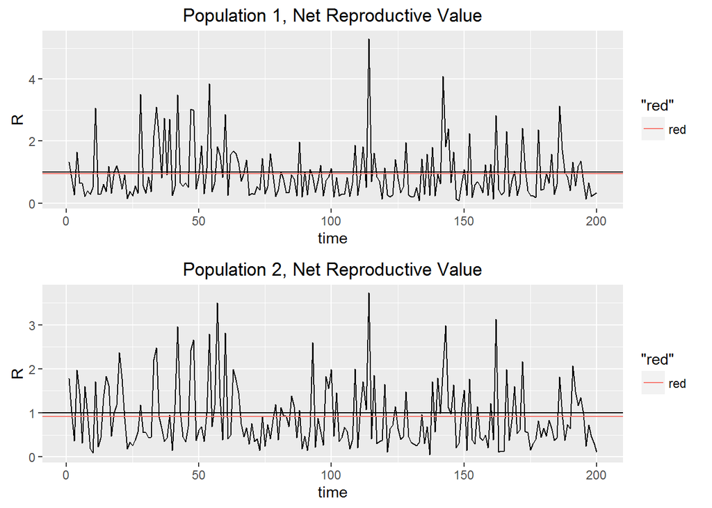

```r
ptm <- proc.time() # for timing the simulation
sim2test <- sim.2pops()
#Radjs (horizontal lines at 1, tipping point betewen geometric growth and decline, and red line at the mean value)
sim2Radj1.plot<-ggplot(melt(sim2test[[1]][['Radj']]),aes(x=1:200,y=value)) +geom_line() +geom_hline(aes(yintercept=1))+ggtitle('Population 1, Net Reproductive Value') +geom_hline(aes(yintercept=mean(value),color='red')) +xlab('time')+ylab('R')
sim2Radj2.plot<-ggplot(melt(sim2test[[2]][['Radj']]),aes(x=1:200,y=value)) +geom_line() +geom_hline(aes(yintercept=1))+geom_hline(aes(yintercept=mean(value),color='red'))+ggtitle('Population 2, Net Reproductive Value') +xlab('time')+ylab('R')
multiplot(sim2Radj1.plot,sim2Radj2.plot)
```

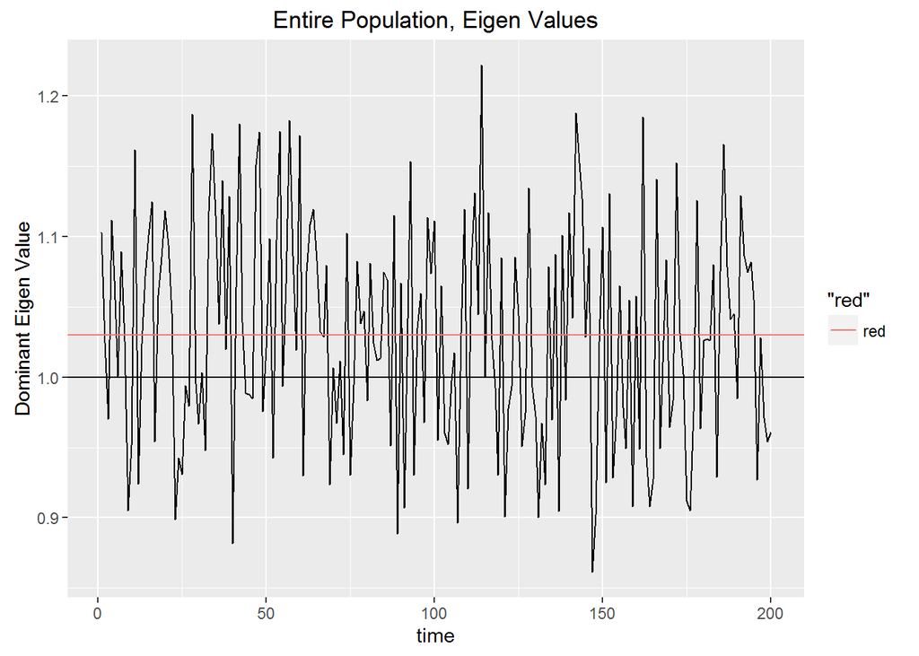

```r
#eigens (horizontal lines at 1, tipping point between geometric growth and decline,and red line at the mean value)
ggplot(melt(sim2test[[3]][['eigens']]),aes(x=1:200,y=value)) +geom_line() +geom_hline(aes(yintercept=1))+geom_hline(aes(yintercept=mean(value),color='red')) +ggtitle('Entire Population, Eigen Values') +xlab('time')+ylab('Dominant Eigen Value')
```

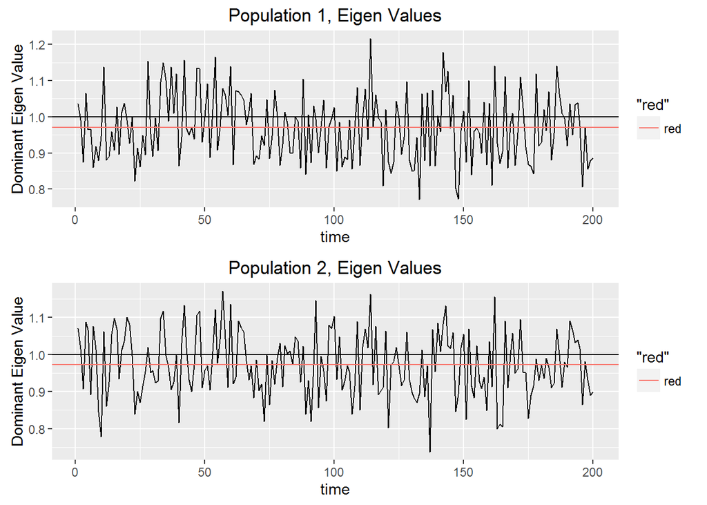

```r
sim2eigens1.plot<-ggplot(melt(sim2test[[1]][['eigens']]),aes(x=1:200,y=value)) +geom_line() +geom_hline(aes(yintercept=1))+ggtitle('Population 1, Eigen Values') +geom_hline(aes(yintercept=mean(value),color='red')) +xlab('time')+ylab('Dominant Eigen Value')
sim2eigens2.plot<-ggplot(melt(sim2test[[2]][['eigens']]),aes(x=1:200,y=value)) +geom_line() +geom_hline(aes(yintercept=1))+ggtitle('Population 2, Eigen Values') +geom_hline(aes(yintercept=mean(value),color='red')) +xlab('time')+ylab('Dominant Eigen Value')
multiplot(sim2eigens1.plot,sim2eigens2.plot)
```

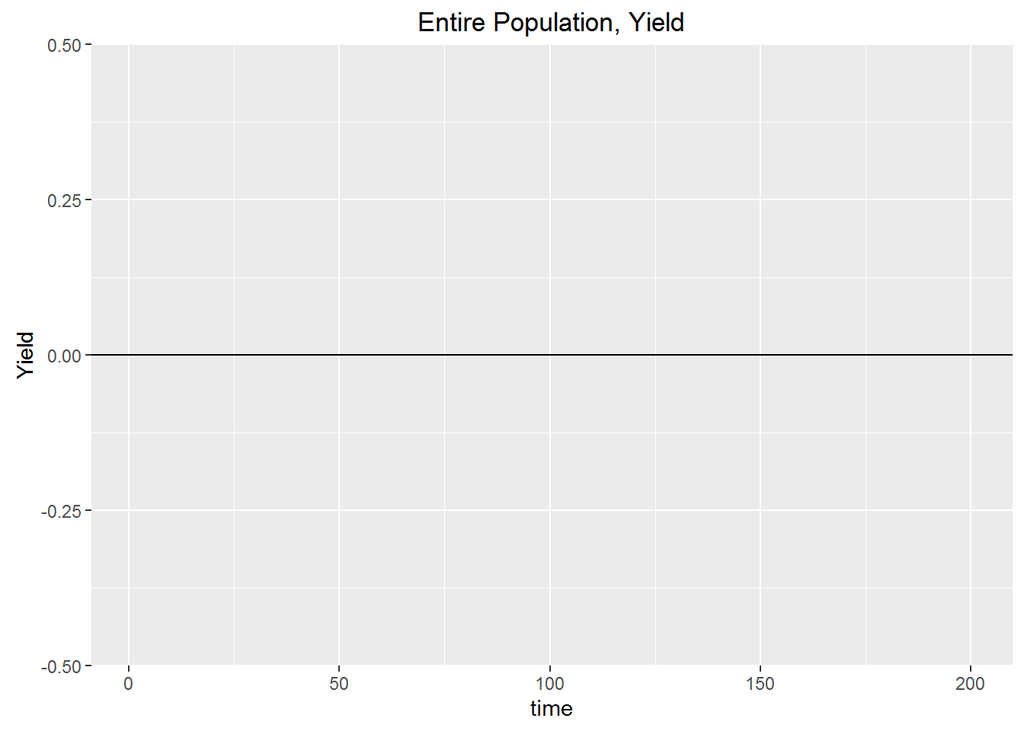

```r
#yield (horizontal lines at the mean value)
ggplot(melt(sim2test[[3]][['Yield']]),aes(x=1:200,y=value)) +geom_line() +geom_hline(aes(yintercept=mean(value))) +ggtitle('Entire Population, Yield') +xlab('time')+ylab('Yield')
```

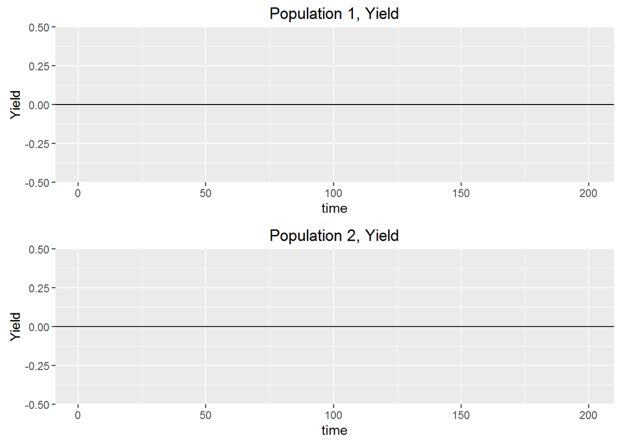

```r
sim2Yield1.plot<-ggplot(melt(sim2test[[1]][['Yield']]),aes(x=1:200,y=value)) +geom_line() +geom_hline(aes(yintercept=mean(value)))+ggtitle('Population 1, Yield') +xlab('time')+ylab('Yield')
sim2Yield2.plot<-ggplot(melt(sim2test[[2]][['Yield']]),aes(x=1:200,y=value)) +geom_line() +geom_hline(aes(yintercept=mean(value)))+ggtitle('Population 2, Yield') +xlab('time')+ylab('Yield')
multiplot(sim2Yield1.plot,sim2Yield2.plot)
```

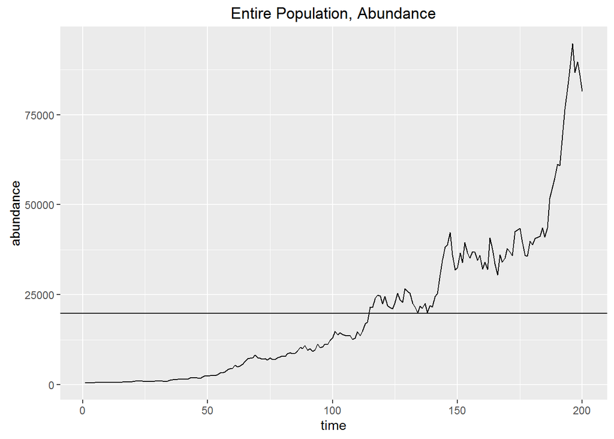

```r
#abundance (horizontal line at the mean value)
ggplot(melt(sim2test[[3]][['tot']]),aes(x=1:200,y=value)) +geom_line() +geom_hline(aes(yintercept=mean(value))) +ggtitle('Entire Population, Abundance') +xlab('time')+ylab('abundance')
```

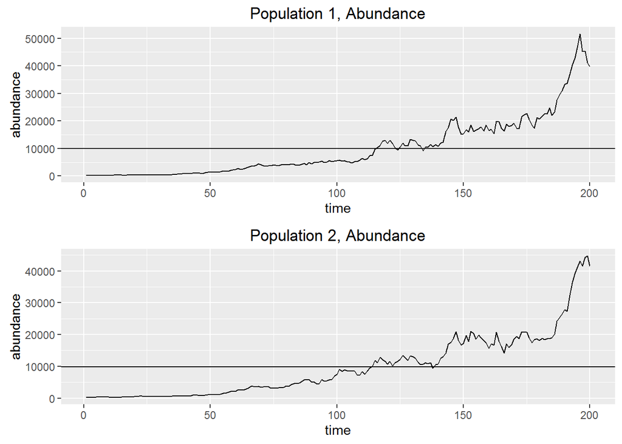

```r
sim2pop1.plot<-ggplot(melt(sim2test[[1]][['tot']]),aes(x=1:200,y=value)) +geom_line() +geom_hline(aes(yintercept=mean(value)))+ggtitle('Population 1, Abundance') +xlab('time')+ylab('abundance')
sim2pop2.plot<-ggplot(melt(sim2test[[2]][['tot']]),aes(x=1:200,y=value)) +geom_line() +geom_hline(aes(yintercept=mean(value)))+ggtitle('Population 2, Abundance') +xlab('time')+ylab('abundance')
multiplot(sim2pop1.plot,sim2pop2.plot)
```

```r
proc.time() - ptm # how much time did the run and plots take?
```

```
##    user  system elapsed
##    1.73    0.07    1.81
```

Note: Interestingly, with the model parameterized in this way, both local populations are “sinks”, meaning that their mean eigen values (and Reproductive Value) are less than 1 (considered alone). But because the populations have larval flow, the entire population displays positive geometric growth.